# Step1. Metacells

In this vignette we generate Metacells, i.e., mini-bulking, to reduce sparseness of and increase the power of the dataset.

# 1 Load libraries

Load the necessary libraries.

```r
library(Seurat)
library(SeuratObject)
library(dplyr)
library(steam)
library(future)
library(ggplot2)
```

# 2 Load data

Load Seurat object.

```r
se <- readRDS("data/human_brain_snRNAseq/se_250_cells_filtered.rds")
se
```

```
## An object of class Seurat
## 21292 features across 7538 samples within 1 assay
## Active assay: RNA (21292 features, 0 variable features)
##  1 layer present: counts
```

```r
head(se[[]])
```

```
##                           orig.ident nCount_RNA nFeature_RNA  ROIGroup
## 10X227_1:CTATCCGAGTGCACCC     10X227       5135         2508 Hindbrain
## 10X387_7:AGCGTATGTAGCGTAG     10X387       2636         1628 Hindbrain
## 10X387_7:TGACGCGTCTTTGCAT     10X387       1676         1176 Hindbrain
## 10X383_6:GTAGCTAAGCAACAAT     10X383       1295          879 Hindbrain
## 10X386_2:AAAGGTACATCCGATA     10X386       2442         1464 Hindbrain
## 10X227_1:TGCGGGTTCAGTGTTG     10X227       3623         2102 Hindbrain
##                           ROIGroupCoarse   ROIGroupFine        roi
## 10X227_1:CTATCCGAGTGCACCC           Pons           Pons Human PnAN
## 10X387_7:AGCGTATGTAGCGTAG Myelencephalon Myelencephalon Human MoAN
## 10X387_7:TGACGCGTCTTTGCAT Myelencephalon Myelencephalon Human MoAN
## 10X383_6:GTAGCTAAGCAACAAT Myelencephalon Myelencephalon Human MoSR
## 10X386_2:AAAGGTACATCCGATA Myelencephalon Myelencephalon Human MoAN
## 10X227_1:TGCGGGTTCAGTGTTG           Pons           Pons Human PnAN
##                           organism_ontology_term_id disease_ontology_term_id
## 10X227_1:CTATCCGAGTGCACCC            NCBITaxon:9606             PATO:0000461
## 10X387_7:AGCGTATGTAGCGTAG            NCBITaxon:9606             PATO:0000461
## 10X387_7:TGACGCGTCTTTGCAT            NCBITaxon:9606             PATO:0000461
## 10X383_6:GTAGCTAAGCAACAAT            NCBITaxon:9606             PATO:0000461
## 10X386_2:AAAGGTACATCCGATA            NCBITaxon:9606             PATO:0000461
## 10X227_1:TGCGGGTTCAGTGTTG            NCBITaxon:9606             PATO:0000461
##                           self_reported_ethnicity_ontology_term_id
## 10X227_1:CTATCCGAGTGCACCC                           HANCESTRO:0005
## 10X387_7:AGCGTATGTAGCGTAG                           HANCESTRO:0005
## 10X387_7:TGACGCGTCTTTGCAT                           HANCESTRO:0005
## 10X383_6:GTAGCTAAGCAACAAT                           HANCESTRO:0005
## 10X386_2:AAAGGTACATCCGATA                           HANCESTRO:0005
## 10X227_1:TGCGGGTTCAGTGTTG                           HANCESTRO:0005
##                           assay_ontology_term_id sex_ontology_term_id
## 10X227_1:CTATCCGAGTGCACCC            EFO:0009922         PATO:0000384
## 10X387_7:AGCGTATGTAGCGTAG            EFO:0009922         PATO:0000384
## 10X387_7:TGACGCGTCTTTGCAT            EFO:0009922         PATO:0000384
## 10X383_6:GTAGCTAAGCAACAAT            EFO:0009922         PATO:0000384
## 10X386_2:AAAGGTACATCCGATA            EFO:0009922         PATO:0000384
## 10X227_1:TGCGGGTTCAGTGTTG            EFO:0009922         PATO:0000384
##                           development_stage_ontology_term_id   donor_id
## 10X227_1:CTATCCGAGTGCACCC                     HsapDv:0000144 H18.30.002
## 10X387_7:AGCGTATGTAGCGTAG                     HsapDv:0000136 H19.30.001
## 10X387_7:TGACGCGTCTTTGCAT                     HsapDv:0000136 H19.30.001
## 10X383_6:GTAGCTAAGCAACAAT                     HsapDv:0000123 H19.30.002
```

[output cut: 57 more lines]

```
## 10X227_1:TGCGGGTTCAGTGTTG  normal Homo sapiens male           pons
##                           self_reported_ethnicity development_stage
## 10X227_1:CTATCCGAGTGCACCC                European 50-year-old stage
## 10X387_7:AGCGTATGTAGCGTAG                European 42-year-old stage
## 10X387_7:TGACGCGTCTTTGCAT                European 42-year-old stage
## 10X383_6:GTAGCTAAGCAACAAT                European 29-year-old stage
## 10X386_2:AAAGGTACATCCGATA                European 42-year-old stage
## 10X227_1:TGCGGGTTCAGTGTTG                European 50-year-old stage
##                           observation_joinid percent.mt percent.rb
## 10X227_1:CTATCCGAGTGCACCC         ^BxfW(*65) 1.36319377   1.616358
## 10X387_7:AGCGTATGTAGCGTAG         cII>Gre!fw 0.03793627   1.479514
## 10X387_7:TGACGCGTCTTTGCAT         M%1q1|NpGe 0.17899761   2.983294
## 10X383_6:GTAGCTAAGCAACAAT         NgInVp!s37 0.30888031   1.621622
## 10X386_2:AAAGGTACATCCGATA         w!3f+7mUG1 0.16380016   1.105651
## 10X227_1:TGCGGGTTCAGTGTTG         Dg_}PJcQ+5 1.46287607   2.539332
```

Check the number of cells per cell type for the cluster annotation you want to create Metacells from. Please note that when creating Metacells, all annotated classes with less than 50 will be excluded using default settings.

```r
table(se$supercluster_term)
```

```
##
##                 Amygdala excitatory                           Astrocyte
##                                 249                                 247
##                       Bergmann glia               Cerebellar inhibitory
##                                 250                                 245
##                     CGE interneuron                      Choroid plexus
##                                 249                                 239
## Committed oligodendrocyte precursor   Deep-layer corticothalamic and 6b
##                                 235                                 246
##       Deep-layer intratelencephalic          Deep-layer near-projecting
##                                 250                                 250
##       Eccentric medium spiny neuron                           Ependymal
##                                 244                                 224
##                          Fibroblast                   Hippocampal CA1-3
##                                 245                                 248
##                     Hippocampal CA4           Hippocampal dentate gyrus
##                                 235                                 249
##           LAMP5-LHX6 and Chandelier                   Lower rhombic lip
##                                 249                                 248
##                     Mammillary body                 Medium spiny neuron
##                                 232                                 248
##                     MGE interneuron                           Microglia
##                                 248                                 240
##         Midbrain-derived inhibitory                       Miscellaneous
##                                 244                                 227
##                     Oligodendrocyte           Oligodendrocyte precursor
##                                 249                                 249
##                            Splatter                 Thalamic excitatory
##                                 247                                 216
##                   Upper rhombic lip      Upper-layer intratelencephalic
##                                 249                                 250
##                            Vascular
##                                 237
```

Check counts

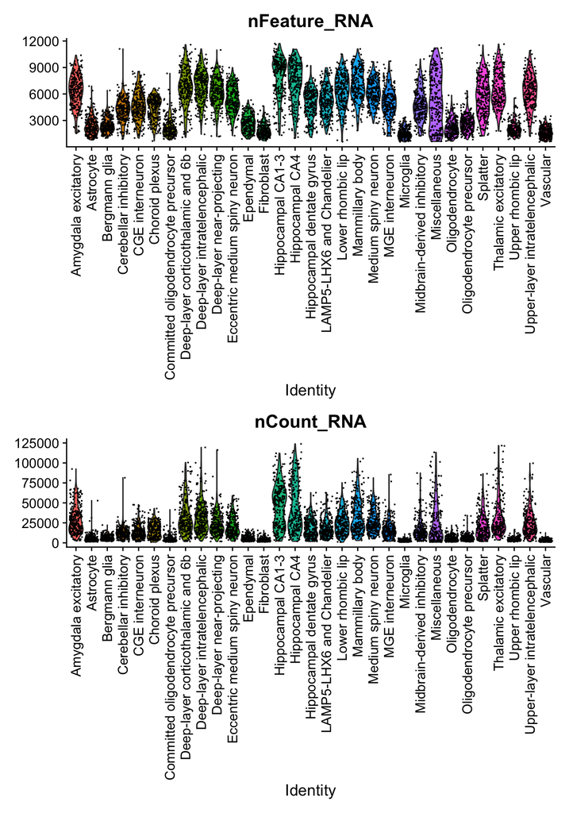

```r
p <- VlnPlot(se, features = c("nFeature_RNA", "nCount_RNA"), ncol = 1, group.by = "supercluster_term")
p & theme(axis.text.x = element_text(angle = 90, hjust = 1, vjust = 0.5))
```